# 3. Grafikoni i boje

U ovoj lekciji naučit ćete:

1. još jedan način za pomicanje stanica unutar Jupyterove radne knjižice;
2. kako prikazati podatke u grafikonima; i
3. kako prikazati grafikone u različitim bojama.

## 3.1. Još malo o Jupyterovoj radnoj knižici

Nekoliko smo puta rekli da se Jupyterova radna knjiga sastoji od niza ćelija, a svaka ćelija može sadržavati tekst, matematički izraz ili niz Python naredbi. Red gumba na vrhu stranice omogućuje vam manipuliranje Jupyterovim radnim knjigama na različite načine. Do sada smo se sreli:

- gumb **Run** koji izvršava ćelije,
- gumb nalik na disketu koji nam omogućava snimanje radne knjižice,
- gumb **+** koji dodaje novu ćeliju ispod aktivne ćelije, i
- strelice gore i dolje koje radnu ćeliju pomiču jedno mjesto gore ili dolje.

Sljedeća tri gumba:

[figure not shown]

omogućuju ćelijama da obavljaju standardne operacije nazvane engleskim *cut* (rez, gumb "škare"), *copy* (iskopiraj, gumb "dva lista papira") i *paste* (zalijepi, "listovi papira koji se dodaju na radnu površinu").

Ako želite **premjestiti ćeliju:**

1. kliknite tu ćeliju,
2. kliknite gumb *cut* (gumb škare),
3. kliknite negdje drugdje u radnoj knjizi za Jupyteru, i na kraju
4. kliknite gumb *paste* (gumb "list papira koji se dodaje radnoj površini").

Ova se operacija ukratko naziva *cut/paste*.

Ova se operacija ukratko naziva *copy/paste*.

## 3.2. Grafikoni

U situacijama kada nema puno podataka, prikladno je prikazati ih nizom stupaca. Takvi se dijagrami nazivaju *grafikoni* ili (na engleskom bar charts).

Budući da ćemo opet crtati grafikon, prvo ćemo predstaviti biblioteku za crtanje grafikona i dati joj kratko ime:

```python
import matplotlib.pyplot as plt
```

Da se podsjetimo: biblioteka nam je dostupna u ovoj radnoj knjižici, ali za drugu radnu knjižicu moramo je ponovo unijeti (iz te radne knjižice).

Pretpostavimo da je jedan student u semestru imao sljedeće ocjene:

| Predmet | Ocjena |
| --- | --- |
| Matematika | 2 |
| Engleski | 4 |
| Likovni | 5 |
| Povijest | 3 |
| Tjelesni | 5 |
| Glazbeni | 4 |
| Tehnička kultura | 5 |

Podatke možemo prikazati pomoću dvije liste:

```python
predmeti = ["Mat", "Eng", "Lik", "Pov", "Tje", "Gla", "Teh"]
ocjene    = [2,        4,     5,      3,      5,    4,       5    ]
```

Grafički ih možemo prikazati nizom stupaca pomoću funkcije `bar`. Ova vrsta dijagrama na engleskom jeziku se zove *bar chart*, a nazivamo ga i grafikoni:

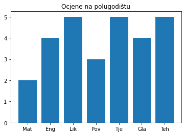

```python
plt.bar(predmeti, ocjene)
plt.title("Ocjene na polugodištu")
plt.show()
plt.close()
```

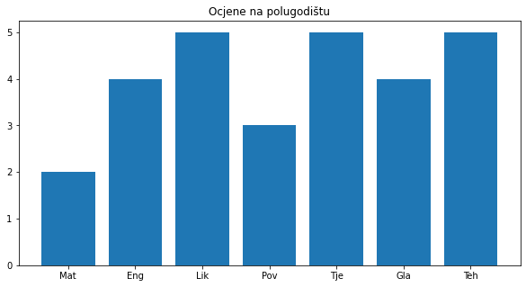

```python
plt.figure(figsize=(10,5))
plt.bar(predmeti, ocjene)
plt.title("Ocjene na polugodištu")
plt.show()
plt.close()
```

Biblioteka crtanja dodjeljuje boju grafikona onako kako to odgovara. Ako nam se ne sviđa boja koju je odabrala knjižnica, boju možemo promijeniti opcijom `color`("boja") promijeniti boju.

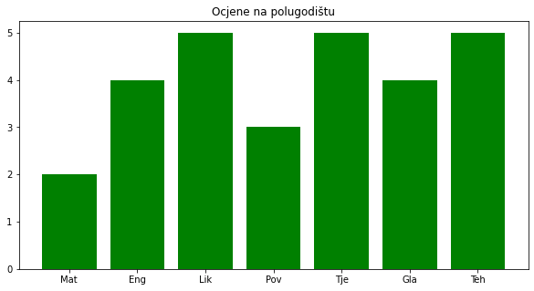

```python
plt.figure(figsize=(10,5))
plt.bar(predmeti, ocjene, color="g")
plt.title("Ocjene na polugodištu")
plt.show()
plt.close()
```

Dijagram je sada nacrtan zelenom bojom ("g" = *green* = zeleno). Možemo koristiti sljedeće boje:

| Slovo | Boja (eng) | Boja (hrv) |
| --- | --- | --- |
| "b" | blue | plava |
| "g" | green | zelena |
| "r" | red | crvena |
| "c" | cyan | svijetloplava |
| "m" | magenta | roza |
| "y" | yellow | žuta |
| "k" | black | crna |
| "w" | white | bijela |

## 3.3. Prikazivanje dvije grupe podataka na istom grafikonu

Na istom je grafikonu moguće prikazati dva skupa podataka. Evo primjera.

"Normalna tjelesna temperatura" zapravo je interval temperatura koji se mijenja s godinama osobe. Kada se temperatura mjeri ispod pazuha, normalna tjelesna temperatura opisana je u sljedećoj tablici:

| Dob | Temperatura ($^\circ$C) |
| --- | --- |
| 0--2 godine | 34.7--37.3 |
| 3--10 godine | 35.9--36.7 |
| 11--65 godine | 35.2--36.9 |
| preko 65 godina | 35.6--36.2 |

U sljedećoj ćeliji iznijeli smo podatke u ovoj tablici sa nizovima:

```python
godine        = ["0-2", "3-10", "11-65", "65+"]
normalnaT_donja = [34.7,  35.9,   35.2,    35.6]
normalnaT_gornja = [37.3,  36.7,   36.9,    36.2]
```

e ćemo podatke prikazati na jednom grafikonu nabrajajući dvije `bar` naredbe:

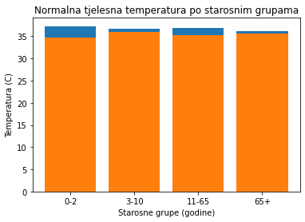

```python
plt.bar(godine, normalnaT_gornja)
plt.bar(godine, normalnaT_donja)
plt.title("Normalna tjelesna temperatura po starosnim grupama")
plt.xlabel("Starosne grupe (godine)")
plt.ylabel("Temperatura (C)")
plt.show()
plt.close()
```

Funkcije `xlabel` i `ylabel` dodavaju napomene na $x$-osi i $y$-osi.

Ovaj je dijagram nečitljiv jer su razlike između donje i gornje granice normalne tjelesne temperature relativno male u usporedbi s podacima koje prikazujemo. Da bismo bolje vidjeli o kojim intervalima govorimo, možemo prikazati samo dio dijagrama koji se odnosi na veličine od recimo 34 stupnja Celzija do 39 stupnjeva Celzija koristeći `ylim` ($y$-limits, što znači, "granica za y-os").

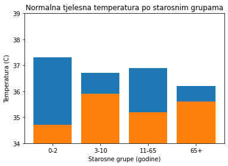

```python
plt.bar(godine, normalnaT_gornja)
plt.bar(godine, normalnaT_donja)
plt.ylim(34,39)
plt.title("Normalna tjelesna temperatura po starosnim grupama")
plt.xlabel("Starosne grupe (godine)")
plt.ylabel("Temperatura (C)")
plt.show()
plt.close()
```

Važno je napomenuti da je redoslijed popisa naredbi `bar` važan jer knjižnica prvo crta više stupove, a preko njih niže! Ako promijenimo redoslijed `bar` naredbi, dobit ćemo dijagram koji ne predstavlja ono što želimo - stupci koji predstavljaju donje granice nisu vidljivi jer je nad njima crtana druga skupina podataka:

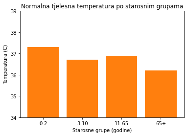

```python
plt.bar(godine, normalnaT_donja)
plt.bar(godine, normalnaT_gornja)
plt.ylim(34,39)
plt.title("Normalna tjelesna temperatura po starosnim grupama")
plt.xlabel("Starosne grupe (godine)")
plt.ylabel("Temperatura (C)")
plt.show()
plt.close()
```

Dakle, moramo ovim redom:

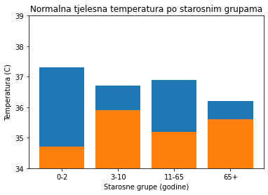

```python
plt.bar(godine, normalnaT_gornja)
plt.bar(godine, normalnaT_donja)
plt.ylim(34,39)
plt.title("Normalna tjelesna temperatura po starosnim grupama")
plt.xlabel("Starosne grupe (godine)")
plt.ylabel("Temperatura (C)")
plt.show()
plt.close()
```

Nekome tko je samo pogledao dijagram i nije pažljivo pročitao tekst prije njega, nije sasvim jasno koje su informacije predstavljene plavom, a koje narančastim trakama. Stoga se u dijagram može dodati legenda koja daje dodatna objašnjenja.

Prvo ćemo u obje naredbe `bar` dodati još jedan parametar `label="objašnjenje"` ", koji ukratko opisuje podatke prikazane na tom dijelu dijagrama. Funkcija `legend` zatim crta legendu na dijagramu:

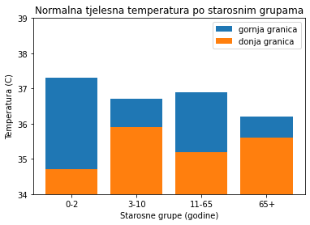

```python
plt.bar(godine, normalnaT_gornja, label="gornja granica")
plt.bar(godine, normalnaT_donja, label="donja granica")
plt.ylim(34,39)
plt.title("Normalna tjelesna temperatura po starosnim grupama")
plt.xlabel("Starosne grupe (godine)")
plt.ylabel("Temperatura (C)")
plt.legend()
plt.show()
plt.close()
```

## 3.4. Zadaci

**Zadatak 1.** Pogledaj sljedeći kod pa odgovori na pitanje:

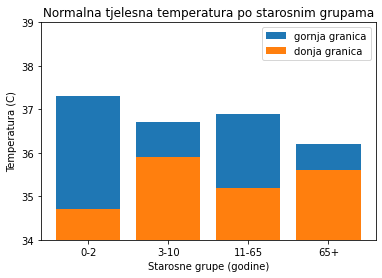

```python
import matplotlib.pyplot as plt
plt.bar(godine, normalnaT_gornja, label="gornja granica")
plt.bar(godine, normalnaT_donja, label="donja granica")
plt.ylim(34,39)
plt.title("Normalna tjelesna temperatura po starosnim grupama")
plt.xlabel("Starosne grupe (godine)")
plt.ylabel("Temperatura (C)")
plt.legend()
plt.show()
plt.close()
```

1. Čemu služi funkcija `bar`?
2. Kako bi izgledao grafikon kada bi dve funkcije `bar` zamijenile mjesta u ovom programu?
3. Čemu služi funkcija `xlabel`?
4. Čemu služi funkcije `ylim` i `legend`?
5. Kako bi promijenio veličinu ovog grafikona (dimenzije pravokutnika u koji je graf pakiran)?
6. Kako bi promijenio boju stupića koji pokazuju gornju granicu u žutu?

Sljedeće zadatke riješi u Jupyteru.

**Zadatak 2.** Prvih deset mjesta na ATP listi na dan 21.07.2019. izgleda ovako:

```python
tennis_players = ["Đoković", "Nadal", "Federer", "Thiem", "Zverev", "Tsipras", "Nishikori", "Khachanov", "Fognini", "Medvedev"]
ATP_points     = [12415,      7945,    7460,      4595,   4325,     4045,       4040,        2890,        2785,      2625]
```

Prikaži grafikon podatke o ATP bodovima prvih 10 tenisača na svijetu.

**Zadatak 3.** Biolozi su do danas opisali oko dva milijuna vrsta živih bića. Svi su podijeljeni u pet carstava. Njihov približan broj po carstvu dan je u sljedećoj tablici:

| Carstvo | Broj vrsta |
| --- | --- |
| Životinje | 1,400,000 |
| Biljke | 290,000 |
| Gljive | 100,000 |
| Protisti | 200,000 |
| Monere | 10,000 |

Prikaži ove podatke grafikonom.

**Zadatak 4.** Sljedeća tablica prikazuje najviše i najniže temperature (in $^\circ$C) ikad izmjerene na kontinentima:

| Kontinent: | Europa | Azija | Afrika | S. Amerika | J. Amerika | Australija | Antarktika |
| --- | --- | --- | --- | --- | --- | --- | --- |
| Najv. zabilježena temp: | 48 | 54 | 55 | 56.7 | 48.9 | 50.7 | 19.8 |
| najn. zabilježena temp: | -58.1 | -67.8 | -23.9 | -63 | -32.8 | -23 | -89.2 |

Prikažite oba niza podataka grafikonima na istom grafikonu. Neka su maksimalne temperature predstavljene crvenom bojom, a minimalne plavom. (Podaci preuzeti s https://www.space.com/17816-earth-temperature.html).

**Zadatak 5.**

*(a)* Na Internetu saznajte što radi `barh` funkcija iz biblioteke `matplotlib`.

*(b)* Ako u rješenju prethodnog zadatka umjesto funkcije `bar` koristiti `barh` funkcija na oba mjesta, kako ćete dobiti graf?.

**Zadatak 6*.** Procjenjuje se da je Kina 01.07.2019. imala 1.420.062.022 stanovnika, a Indija 1,368,737,513. Kinesko se stanovništvo svake godine povećava za 0,35%, a u Indiji 1,08%. Na istom dijagramu prikazujte očekivani broj stanovnika Kine i Indije u sljedećih deset godina, grafičkim crtama, pod pretpostavkom da se godišnji rast stanovništva u bilo kojoj od ove dvije zemlje neće promijeniti.

Nakon koliko godina će Indija nadmašiti Kinu po broju stanovnika? Kako se to može vidjeti iz grafikona?

© 2019 [Petlja.org](https://petlja.org)